# insight

```python
from IPython.display import display
from IPython.display import HTML
import IPython.core.display as di # Example: di.display_html('<h3>%s:</h3>' % str, raw=True)

# This line will hide code by default when the notebook is exported as HTML
di.display_html('<script>jQuery(function() {if (jQuery("body.notebook_app").length == 0) { jQuery(".input_area").toggle(); jQuery(".prompt").toggle();}});</script>', raw=True)

# This line will add a button to toggle visibility of code blocks, for use with the HTML export version
di.display_html('''<button onclick="jQuery('.input_area').toggle(); jQuery('.prompt').toggle();">Toggle code</button>''', raw=True)
```

```python
import pandas as pd
import numpy as np
import matplotlib.pyplot as plt
from matplotlib import cm
import matplotlib.patches as mpatches
pd.set_option('display.max_colwidth',1000)
%matplotlib inline
```

## Introduction

#### This study is done by Jiwei Liu and Xueer Chen, part of the team better luck in 2016, 6th place of the Genentech Cervical Cancer Screening contest. We first study the impact of leaks, absence of a claim line in either diagnosis_head or procedure_head in the datasets, and show that their predicting power is dominant. Therefore in the following analysis we remove all the records with leak features to better identify other important features. We modified Follow the Regularized Leader (FTRL) algorithm to extract important features and feature interactions in an online fashion. Our approach can find both leak and good features automatically without any prior domain knowledge.

### In summary, we make the following insights:

#### 2. Most useful features are code features: diagnosis code, procedure code, surgical code and their interactions.

Diagnosis code and procedure code pairs linked by the same claim ID can be a strong indicator of screeners. Specifically, the algorithm found 109 code pairs that correspond to more than 90% screener rate, 41 of which correspond to +99% screener rate.

A single diagnosis code, procedure code or surgical code is also a good indicator of screeners but much more frequent in data sets. The algorithm found 27 such single codes that correspond to more than 80% screener rate, with frequency (percentage of patients who have these features) ranging from 1% to 14%

A single procedure code or a code pair can be a good indicator of non-screeners. The algorithm found 4 codes and 5 pairs which correspond to less than 30% screener rate and more than 0.01% frequency. The algorithm also found 34 such codes and pairs that correspond to 0 screener rate but they are extremely infrequent.

#### 3. There are some "hidden" examinations that might indicate the necessity of cervical cancer examination.

"ASSAY OF THYROID STIMULATING HORMONE TSH" is kind of surprising as this test is usually for evaluating thyroid function rather than cervical cancer relevant test; our model recognizes that people have this test are more likely to be screeners; out of curiosity, we found a research on "Expression of Thyroid Stimulating Hormone in Cervical Epithelial Cells" indicating that these two are related, they hypothesized that TSH may play a role in the mechanism of action of human papilloma virus infection in cervical epithelia, and subsequent tumorigenesis.

#### 4. People with acute diseases are less likely to have screeners.

We can explain this by a "mutual exclusive" concept, i.e., people already occupied with acute/chronic diseases are not likely to have the necessity or efforts to care about other severe diseases (cervical cancer), either the possibility they have cervical cancer given they already have other acute diseases are lower, or they don't have the efforts to realize they need to do regular screening.

#### 5. Special populations might need help on screening.

We find people with mental diseases or gender identity disorder are less likely to be screeners; for people have mental diseases, they may have difficulties recognizing the necessity of having examination themselves, thus people who take care of them such as families or healthcare professionals should help them; for people with gender identity disorder, they also need appropriate education on proper examination for them.

#### 6. Some practitioners' job directly relates to screening or cervical cancer.

For example, practitioner "16444459", "12709441", and "14015592" are doing DIAGNOSTIC RADIOLOGY and OBSTETRICS AND GYNECOLOGY and they correspond to +90% screener rate!

#### 7. Nurse's experience matters

For example, NMW, NURSE MIDWIFE, advanced practice registered nurses, correspond to 81% screener rate while SNP, SCHOOL NURSE PRACTITIONER, correspond to only 25% screener rate

### Preprocess the data, using pypy.

```python
# preprocess the data
# 50 GB memory required
# should take less than 2 hours.
import os
os.system('sh run.sh')
# this will generate the following feature files in ../online2/
# All of them have the same format, please refer cell 4 for detailed explanations
# feamap8.csv, extracted features with leak
# All following files are extracted after leak records are removed
# feamap9.csv, diagnosis code, procedure code and their interactions
# feamap10.csv, sugical code
# feamap11.csv, non-code features in diagnosis_head.csv
# feamap12.csv, features from physicians.csv
```

```
0
```

## Insight 1: Leak is dominant

### Model performance

#### Unfortunately there is leak in this data set. So how bad is it?

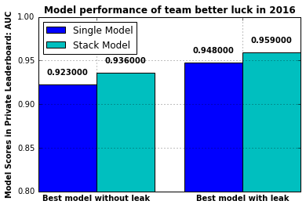

```python
N = 2
stack_score = np.array([0.936,0.959])# rstack19.csv 0.936, ave37.csv 0.959
single_score = np.array([0.923,0.948])#submission4.csv 0.923, old_bucket-submission6 0.948
ind = np.arange(N)  # the x locations for the groups
width = 0.4       # the width of the bars
fig, ax = plt.subplots()
rects1 = ax.bar(ind, single_score, width,  color='b')#color='r')
rects2 = ax.bar(ind+width, stack_score, width,  color='c')
ax.set_ylabel('Model Scores in Private Leaderboard: AUC',fontweight='bold')
ax.set_title('Model performance of team better luck in 2016',fontweight='bold')
ax.set_xticks(ind+width)
ax.set_xticklabels(('Best model without leak', 'Best model with leak'),fontweight='bold')
plt.grid()
ax.set_ylim(0.8,1.0)
ax.legend((rects1[0], rects2[0]), ('Single Model', 'Stack Model'),loc='upper left')
def autolabel(rects):
    for c,rect in enumerate(rects):
        height = rect.get_height()
        ax.text(rect.get_x() + rect.get_width()/2., 1.01*height,
                '%f' % height,
                ha='center', va='bottom',fontweight='bold')
autolabel(rects1)
autolabel(rects2)
plt.show()
```

#### Conclusion: the leak will boost the model auc score by at least 0.02.

## A closer look at leak

#### We extract 400 most important features using ftrl from diagnosis_head.csv and procedure_head.csv, which only include occurrences of diagnosis codes, procedure codes and their interactions. With these 400 features, a ftrl model can get 0.908 auc in less than 10 minutes. Features are extracted based on their weight in the ftrl model: the greater absolute value of the weight, the more important the feature.

#### The features can be divided into three categories:

1. the occurrence of a single diagnosis/procedure code
2. the occurrence of a pair of a diagnosis code and a procedure code connected by the same claim id.
3. the occurrence of a pair of a diagnosis code and a missing procedure code connected by the same claim id.

#### As we know, type 3) the missing code or entire procedure entries are actually leaks.

```python
fea=pd.read_csv('../online2/feamap8.csv').sort(columns='frequency',axis=0,ascending=False)
fea['is_leak']=fea.feature.map(str).apply(lambda x: x[-1]=='_').astype(int)
fea['is_positive']=fea.weight>0
fea[:10]
```

|  | index | feature | weight | screen_rate | frequency | description | is_leak | is_positive |
| --- | --- | --- | --- | --- | --- | --- | --- | --- |
| 162 | 167930709 | V72.31 | 0.557454 | 0.825552 | 0.492814 | ROUTINE GYNECOLOGICAL EXAMINATION | 0 | True |
| 253 | 253625570 | 88305 | 0.117017 | 0.643462 | 0.373726 | p:LEVEL IV SURG PATHOLOGY GROSS&MICROSCOPIC EXAM | 0 | True |
| 87 | 27787726 | V70.0 | 0.105387 | 0.695280 | 0.302872 | ROUTINE GENERAL MEDICAL EXAMINATION AT A HEALTH CARE FACILITY | 0 | True |
| 164 | 141421400 | 99396 | 0.111948 | 0.728219 | 0.276361 | p:PERIODIC PREVENTIVE MED EST PATIENT 40-64YRS | 0 | True |
| 86 | 105611720 | V72.31_ | 2.977993 | 0.998394 | 0.233918 | ROUTINE GYNECOLOGICAL EXAMINATION | 1 | True |
| 267 | 21665063 | V72.31_99396 | -0.407650 | 0.775715 | 0.169847 | ROUTINE GYNECOLOGICAL EXAMINATION \|\|\|\| PERIODIC PREVENTIVE MED EST PATIENT 40-64YRS | 0 | False |
| 266 | 21665062 | V72.31_99395 | -0.333932 | 0.839669 | 0.100202 | ROUTINE GYNECOLOGICAL EXAMINATION \|\|\|\| PERIODIC PREVENTIVE MED EST PATIENT 18-39 YRS | 0 | False |
| 271 | 105844015 | 87491 | 0.658191 | 0.905852 | 0.098132 | p:IADNA CHLAMYDIA TRACHOMATIS AMPLIFIED PROBE TQ | 0 | True |
| 327 | 187770410 | 87591 | 0.640004 | 0.905743 | 0.095544 | p:IADNA NEISSERIA GONORRHOEAE AMPLIFIED PROBE TQ | 0 | True |
| 181 | 210008996 | 87081 | 0.113113 | 0.779744 | 0.073474 | p:CUL PRSMPTV PTHGNC ORGANISM SCRN W/COLONY ESTIMJ | 0 | True |

feamap8.csv is the feature selection result from ftrl which include important codes and codes interactions. All original occurrences of codes and their interactions are mapped/hashed to 2^28 feature space.

1. The column 'index' indicates the feature's index in the 2^28 feature space.
2. The column 'feature' indicates the content of the feature, from which we can tell the 3 types. For example, V77.71 is the 1st type or occurrence of a single diagnosis code. 'V76.41*G0328' is the 2nd type or a pair of codes. V76.41 is a diagnosis code and G0328 is a procedure code and they are connected by the same claim_id. 'V88.01*' is the 3rd type or a leak feature. V88.01 is a diagnosis code but the corresponding procedure code with the same claim_id is missing.
3. The column 'weight' stands for the feature weight in ftrl model. A positive/negative weight indicates a screener/non-screener accordingly.
4. The column 'screen_rate' indicates the percentage of screeners in patients whose records include this feature at least once.
5. The column 'frequency' indicates the percentage of patients whose records include this feature at least once out of all the patients
6. The column 'description' includes the descriptions of the codes. For code pairs descriptions are in the format of "diagnosis code description |||| procedure code description"
7. The column 'is_leak' indicates whether the feature is a leak feature. (diagnosis_code + missing procedure code of a claim)
8. The column 'is_positive' indicates if a feature has a positive weight

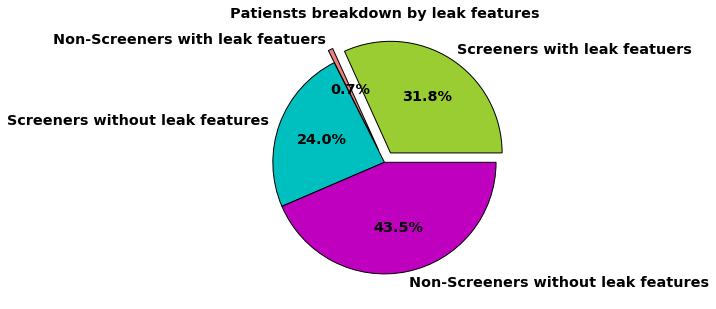

```
number of leak features 79 , number of non-leak features 325
```

```python
from matplotlib import font_manager as fm
proptease = fm.FontProperties()
proptease.set_size('x-large')
proptease.set_weight('bold')
fig = plt.figure(figsize=(15,5))

import csv
a,b,c,d=0,0,0,0
for row in csv.DictReader(open('../online2/features/fea8.csv')):
    flag=0
    for x in row['features'].split():
        if x[-1]=='_':
            flag=1
            break
    if flag:
        if float(row['is_screener'])>0:
            a+=1
        else:
            b+=1
    else:
        if float(row['is_screener'])>0:
            c+=1
        else:
            d+=1
ax3 = fig.add_subplot(121)
labels = 'Screeners with leak featuers', 'Non-Screeners with leak featuers','Screeners without leak features','Non-Screeners without leak features'
sizes = a,b,c,d
colors = ['yellowgreen', 'lightcoral','c','m']
explode = ( 0.1, 0.12,0,0)
patches, texts3, autotexts3 = ax3.pie(sizes,explode=explode, labels=labels, colors=colors, autopct='%1.1f%%')
ax3.set_title('Patiensts breakdown by leak features',fontproperties=proptease)
plt.setp(autotexts3, fontproperties=proptease)
plt.setp(texts3, fontproperties=proptease)



fig.subplots_adjust(wspace=1)
plt.show()
print 'number of leak features',fea[fea['is_leak']>0].shape[0],', number of non-leak features',fea[fea['is_leak']<1].shape[0]
```

#### This figure shows that 31.8% patients who have leak features in their records are also screeners and only 0.7% patients who have leak features are not screeners. In other words, 97.8% patients who have leak features are screeners. Since we didn't consider another leak case in this part, that a claim is present in procedure but not diagnosis, the actual patients with leak features could be more than the figure showed.

#### Out of 404 important features 19.6% (79) are leak features, out of which 97.5% leak features indicate screeners.

#### Next, let's find out what code pairs indicate strong leak.

```python
leak=fea[fea.is_leak>0].sort(columns='frequency',axis=0,ascending=False)
leak_single=leak[leak['feature'].apply(lambda x:x[:-1]).isin(fea['feature'])]
leak_single['single_feature']=leak_single['feature'].apply(lambda x:x[:-1])
fea['single_feature']=fea['feature']
fea['single_screen_rate']=fea['screen_rate']
fea['single_frequency']=fea['frequency']
leak_single=pd.merge(leak_single,fea[['single_screen_rate','single_feature','single_frequency']],on='single_feature',how='left')
print leak.shape, leak_single.shape
```

```
(79, 8) (46, 11)
```

```python
#leak_single.head()
```

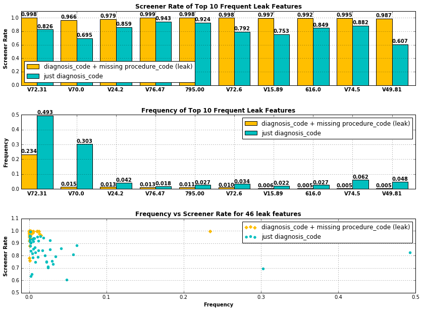

```
mean screener rate for leak features 0.975095478261 summed frequency of leakfeatures 0.356516
```

```python
N = 10
leak_sr = leak_single.screen_rate[:N]#
single_sr = leak_single.single_screen_rate[:N]#
xlabelname= leak_single.single_feature[:N]
ind = np.arange(N)  # the x locations for the groups
width = 0.4       # the width of the bars

fig = plt.figure(figsize=(14,10))
ax = fig.add_subplot(311)

#fig, ax = plt.subplots()

rects1 = ax.bar(ind, leak_sr, width,  color='#FFBF00')#color='r')
rects2 = ax.bar(ind+width, single_sr, width,  color='c')
ax.set_ylabel('Screener Rate',fontweight='bold')
ax.set_title('Screener Rate of Top 10 Frequent Leak Features',fontweight='bold')
ax.set_xticks(ind+width)
ax.set_xticklabels(xlabelname,fontweight='bold')
plt.grid()
ax.set_ylim(0.,1.10)
ax.legend((rects1[0], rects2[0]), ('diagnosis_code + missing procedure_code (leak)', 'just diagnosis_code'),loc='lower left')
def autolabel(rects,ax):
    for c,rect in enumerate(rects):
        height = rect.get_height()
        ax.text(rect.get_x() + rect.get_width()/2., 1.01*height,
                '%.3f' % float(height),
                ha='center', va='bottom',fontweight='bold')
autolabel(rects1,ax)
autolabel(rects2,ax)

ax1 = fig.add_subplot(312)
leak_fr = leak_single.frequency[:N]#
single_fr = leak_single.single_frequency[:N]

rects1 = ax1.bar(ind, leak_fr, width,  color='#FFBF00')#color='r')
rects2 = ax1.bar(ind+width, single_fr, width,  color='c')
ax1.set_ylabel('Frequency',fontweight='bold')
ax1.set_title('Frequency of Top 10 Frequent Leak Features',fontweight='bold')
ax1.set_xticks(ind+width)
ax1.set_xticklabels(xlabelname,fontweight='bold')
plt.grid()
#ax.set_ylim(0.,1.10)
ax1.legend((rects1[0], rects2[0]), ('diagnosis_code + missing procedure_code (leak)', 'just diagnosis_code'),loc='upper right')

autolabel(rects1,ax1)
autolabel(rects2,ax1)

ax2 = fig.add_subplot(313)
ax2.scatter(leak_single.frequency,leak_single.screen_rate,color='#FFBF00',marker='D',s=20,label='diagnosis_code + missing procedure_code (leak)')
ax2.scatter(leak_single.single_frequency,leak_single.single_screen_rate,color='c',label='just diagnosis_code',s=20)
ax2.legend(loc='upper right')
plt.xlim(-0.01,0.5)
plt.ylim(0.5,1.1)
ax2.set_title('Frequency vs Screener Rate for 46 leak features',fontweight='bold')
ax2.set_ylabel('Screener Rate',fontweight='bold')
ax2.set_xlabel('Frequency',fontweight='bold')
plt.grid()

fig.subplots_adjust(hspace=0.4)
plt.show()
print 'mean screener rate for leak features',leak_single.screen_rate.mean(),'summed frequency of leakfeatures',leak_single.frequency.sum()
```

## Insight 2: Most useful features are code features: diagnosis code, procedure code, surgical code and code pairs

```python
nonleak=pd.read_csv('../online2/feamap9.csv')
nonleak=nonleak.append(pd.read_csv('../online2/feamap10.csv')).drop_duplicates(cols='feature', take_last=True)
nonleak.sort(columns='frequency',axis=0,ascending=False)
nonleak['is_leak']=nonleak.feature.map(str).apply(lambda x: x[-1]=='_').astype(int)
nonleak['is_positive']=nonleak.weight>0
print nonleak.shape, nonleak[nonleak['is_leak']==0].shape
```

```
(734, 8) (734, 8)
```

```python
mask1=nonleak.feature.apply(lambda x:'_' in x)
mask2=nonleak.description.apply(lambda x:x.startswith('p:'))
mask3=nonleak.description.apply(lambda x:x.startswith('s:'))
mask4=(~mask2)&(~mask1)&(~mask3)
nonleak['feature_type']=nonleak['feature']
nonleak.loc[mask1,'feature_type']='code_pair'
nonleak.loc[mask2,'feature_type']='procedure_code'
nonleak.loc[mask3,'feature_type']='surgical_code'
nonleak.loc[mask4,'feature_type']='diagnosis_code'
```

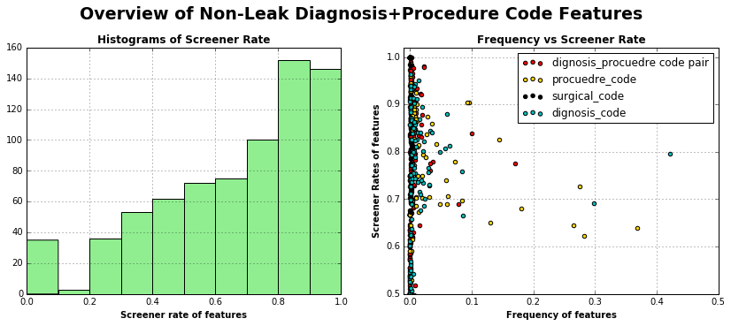

```python
fig = plt.figure(figsize=(14,5))
fig.suptitle('Overview of Non-Leak Diagnosis+Procedure Code Features',fontweight='bold',fontsize=19, y=1.03)
ax = fig.add_subplot(121)
ax.hist(nonleak.screen_rate, color='lightgreen')
ax.set_title('Histograms of Screener Rate',fontweight='bold')
ax.set_xlabel('Screener rate of features',fontweight='bold')
#plt.ylim(0,110)
plt.grid()
#plt.show()

ax2 = fig.add_subplot(122)
ax2.scatter(nonleak.frequency[mask1],nonleak.screen_rate[mask1],c='r',label='dignosis_procuedre code pair')
ax2.scatter(nonleak.frequency[mask2],nonleak.screen_rate[mask2],c='gold',label='procuedre_code')
ax2.scatter(nonleak.frequency[mask3],nonleak.screen_rate[mask3],c='black',label='surgical_code')
ax2.scatter(nonleak.frequency[mask4],nonleak.screen_rate[mask4],c='c',label='dignosis_code')
ax2.set_title('Frequency vs Screener Rate',fontweight='bold')
ax2.set_xlabel('Frequency of features',fontweight='bold')
ax2.set_ylabel('Screener Rates of features',fontweight='bold')
ax2.legend(loc='upper right')
plt.xlim(-0.01,0.5)
plt.ylim(0.5,1.02)
plt.grid()
fig.subplots_adjust(wspace=0.2)
plt.show()
```

#### First, let's take a close look at the procedure codes with frequency greater than 0.1

```python
nonleak[(nonleak.frequency>0.1)&(nonleak.feature_type=='procedure_code')].sort(columns='screen_rate',axis=0,ascending=False)
```

|  | index | feature | weight | screen_rate | frequency | description | is_leak | is_positive | feature_type |
| --- | --- | --- | --- | --- | --- | --- | --- | --- | --- |
| 269 | 141421397 | 99395 | 0.182217 | 0.826148 | 0.145080 | p:PERIODIC PREVENTIVE MED EST PATIENT 18-39 YRS | 0 | True | procedure_code |
| 270 | 141421400 | 99396 | 0.159637 | 0.727765 | 0.275899 | p:PERIODIC PREVENTIVE MED EST PATIENT 40-64YRS | 0 | True | procedure_code |
| 300 | 210008995 | 87086 | 0.094313 | 0.680451 | 0.180286 | p:CULTURE BACTERIAL QUANTTATIVE COLONY COUNT URINE | 0 | True | procedure_code |
| 441 | 192859443 | 82306 | 0.086656 | 0.650494 | 0.129413 | p:25 HYDROXY INCLUDES FRACTIONS IF PERFORMED | 0 | True | procedure_code |
| 354 | 139713571 | 84443 | 0.088933 | 0.645343 | 0.265162 | p:ASSAY OF THYROID STIMULATING HORMONE TSH | 0 | True | procedure_code |
| 411 | 253625570 | 88305 | 0.136199 | 0.638884 | 0.368906 | p:LEVEL IV SURG PATHOLOGY GROSS&MICROSCOPIC EXAM | 0 | True | procedure_code |
| 326 | 9827293 | 80061 | 0.097111 | 0.623372 | 0.281992 | p:LIPID PANEL | 0 | True | procedure_code |

## Insight 3: There are some "hidden" examinations that might indicate the necessity of cervical cancer examination.

#### Taken from table above, we found the following features interesting:

```
1. PERIODIC PREVENTIVE MED EST PATIENT
2. ASSAY OF THYROID STIMULATING HORMONE TSH
3. LEVEL IV SURG PATHOLOGY GROSS&MICROSCOPIC EXAM
4. LIPID PANEL
```

#### The insights are:

```
1. Women who have "PERIODIC PREVENTIVE MED EST PATIENT" are more likely to be screeners
2. "ASSAY OF THYROID STIMULATING HORMONE TSH" is kind of surprising as this test is usually for evaluating thyroid function rather than cervical cancer relevant test; our model recognizes that people have this test are more likely to be screeners; out of curiosity, we found a research on "Expression of Thyroid Stimulating Hormone in Cervical Epithelial Cells" indicating that these two are related, they hypothesized that TSH may play a role in the mechanism of action of human papilloma virus infection in cervical epithelia, and subsequent tumorigenesis. [ref: http://oaktrust.library.tamu.edu/handle/1969.1/154992]
3. "LEVEL IV SURG PATHOLOGY GROSS&MICROSCOPIC EXAM" may indicate that patients have gone through (cervical-related) sugeries [ref: http://a1.mayomedicallaboratories.com/webjc/attachments/53/05c49d7-surgical-pathology.pdf]
4. "LIPID PANEL" is a blood test that might be prescribed to patients to check their cervical carcinoma status
```

```python
print 'All:%d, diagnosis_procedure code pair:%d, diagnosis_code:%d, procedure_code:%d, surgical_code:%d'%\
      (nonleak.shape[0],nonleak[mask1].shape[0],nonleak[mask4].shape[0],nonleak[mask2].shape[0],nonleak[mask3].shape[0])
#nonleak[mask1].to_csv('non_leak_code_pair.csv',index=False)
```

```
All:734, diagnosis_procedure code pair:438, diagnosis_code:135, procedure_code:111, surgical_code:50
```

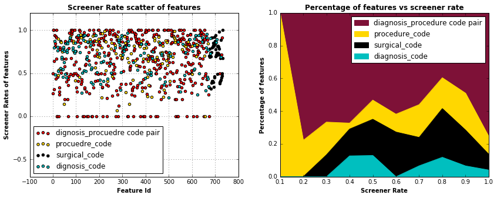

```python
# anotate interesting points, miaomiao ᗦ↞◃
fig = plt.figure(figsize=(14,5))
ax2 = fig.add_subplot(121)
nonleak['feature_id']=np.arange(nonleak.shape[0])
ax2.scatter(nonleak.feature_id[mask1],nonleak.screen_rate[mask1],c='r',label='dignosis_procuedre code pair')
ax2.scatter(nonleak.feature_id[mask2],nonleak.screen_rate[mask2],c='gold',label='procuedre_code')
ax2.scatter(nonleak.feature_id[mask3],nonleak.screen_rate[mask3],c='black',label='surgical_code')
ax2.scatter(nonleak.feature_id[mask4],nonleak.screen_rate[mask4],c='c',label='dignosis_code')
ax2.set_title('Screener Rate scatter of features',fontweight='bold')
ax2.set_xlabel('Feature Id',fontweight='bold')
ax2.set_ylabel('Screener Rates of features',fontweight='bold')
ax2.legend(loc='lower left')
plt.ylim(-0.7,1.2)
plt.grid()

x,y,z,g=[],[],[],[]
x0=np.arange(1,11)*0.1
for i in range(1,11):
    bar=i*0.1

    mask=(nonleak.screen_rate<=bar)&(nonleak.screen_rate>bar-0.1)
    x.append(nonleak[mask1&mask].shape[0])
    y.append(nonleak[mask2&mask].shape[0])
    z.append(nonleak[mask3&mask].shape[0])
    g.append(nonleak[mask4&mask].shape[0])
    s=x[-1]+y[-1]+z[-1]+g[-1]
    x[-1]=x[-1]*1.0/s
    y[-1]=y[-1]*1.0/s
    z[-1]=z[-1]*1.0/s
    g[-1]=g[-1]*1.0/s
x,y,z,g=np.array(x),np.array(y),np.array(z),np.array(g)
ax3 = fig.add_subplot(122)
ax3.plot(x0,x+y+z+g,c='#7E1137',label='dignosis_procuedre code pair')
ax3.plot(x0,y+z+g,c='gold',label='procuedre_code')
ax3.plot(x0,z+g,c='black',label='surgical_code')
ax3.plot(x0,z,c='c',label='dignosis_code')
ax3.fill_between(x0, y+z+g, x+y+z+g,color='#7E1137')
ax3.fill_between(x0, z+g, y+z+g,color='gold')
ax3.fill_between(x0, z, z+g,color='black')
ax3.fill_between(x0, 0, z,color='c')
plt.legend([mpatches.Patch(color='#7E1137'),
            mpatches.Patch(color='gold'),
            mpatches.Patch(color='black'),
            mpatches.Patch(color='c')],
           ['diagnosis_procedure code pair', 'procedure_code', 'surgical_code', 'diagnosis_code'])
ax3.set_xlabel('Screener Rate',fontweight='bold')
ax3.set_ylabel('Percentage of features',fontweight='bold')
ax3.set_title('Percentage of features vs screener rate',fontweight='bold')
fig.subplots_adjust(wspace=0.2)
plt.show()
# add conclusions/explanations of two figures, miaomiao ᗦ↞◃
```

#### The scatter plot gives a better view of the distribution of these features. It shows that code pairs tend to have extremely high and low screener rate. Part of this is due to the fact that such pairs are very infrequent in the datasets. Most diagnosis_code correspond to screener rate greater than 0.5. Most features that correspond to screener rate less than 0.5 are procedure codes and code pairs. Some surgical codes also strongly indicate screeners.

#### The area plot on the right shows the percentage of each type of features at different screener rate zone. It clearly shows that in screener rate zone [0,0.2] procedure codes and code pairs are the majority and they strongly indicate non-screeners while all of 4 types have codes that strongly indicate screeners, out of which code pairs is the majority.

#### Top 10 Strong and Frequent Indicators of Screeners

```python
mask=nonleak.frequency>0.01
nonleak[mask].sort(columns='screen_rate',axis=0,ascending=False)[['feature','screen_rate','description','frequency','feature_type']][:10]
```

|  | feature | screen_rate | description | frequency | feature_type |
| --- | --- | --- | --- | --- | --- |
| 244 | V72.31_87491 | 0.980587 | ROUTINE GYNECOLOGICAL EXAMINATION \|\|\|\| IADNA CHLAMYDIA TRACHOMATIS AMPLIFIED PROBE TQ | 0.022601 | code_pair |
| 341 | V72.31_87591 | 0.978956 | ROUTINE GYNECOLOGICAL EXAMINATION \|\|\|\| IADNA NEISSERIA GONORRHOEAE AMPLIFIED PROBE TQ | 0.022122 | code_pair |
| 663 | 622.11 | 0.950659 | MILD DYSPLASIA OF CERVIX | 0.013373 | diagnosis_code |
| 537 | V22.1_87491 | 0.934735 | SUPERVISION OF OTHER NORMAL PREGNANCY \|\|\|\| IADNA CHLAMYDIA TRACHOMATIS AMPLIFIED PROBE TQ | 0.010309 | code_pair |
| 75 | 57454 | 0.925105 | p:COLPOSCOPY CERVIX BX CERVIX & ENDOCRV CURRETAGE | 0.010091 | procedure_code |
| 356 | V74.5_87591 | 0.923598 | SCREENING EXAMINATION FOR VENEREAL DISEASE \|\|\|\| IADNA NEISSERIA GONORRHOEAE AMPLIFIED PROBE TQ | 0.017070 | code_pair |
| 433 | V74.5_87491 | 0.921770 | SCREENING EXAMINATION FOR VENEREAL DISEASE \|\|\|\| IADNA CHLAMYDIA TRACHOMATIS AMPLIFIED PROBE TQ | 0.017488 | code_pair |
| 664 | 622.10 | 0.912395 | DYSPLASIA OF CERVIX, UNSPECIFIED | 0.010766 | diagnosis_code |
| 439 | 87491 | 0.903392 | p:IADNA CHLAMYDIA TRACHOMATIS AMPLIFIED PROBE TQ | 0.095329 | procedure_code |
| 525 | 87591 | 0.903227 | p:IADNA NEISSERIA GONORRHOEAE AMPLIFIED PROBE TQ | 0.092757 | procedure_code |

This table shows the top 10 strong and frequent indicators: these indicators agree with common sense as they are all related to cervical cancer.

#### Top 10 Strong and Frequent Indicators of Non-Screeners

```python
mask=nonleak.frequency>0.0001
nonleak[mask].sort(columns='screen_rate',axis=0)[['feature','screen_rate','description','frequency','feature_type']][:10]
```

|  | feature | screen_rate | description | frequency | feature_type |
| --- | --- | --- | --- | --- | --- |
| 211 | G0164 | 0.221326 | p:SKILLED SERVICES OF A LICENSED NURSE (LPN OR RN) | 0.000964 | procedure_code |
| 426 | A0800 | 0.222222 | p:AMB TRANSPORT PROV BETWN HR 7PM&7AM | 0.000132 | procedure_code |
| 405 | 585.6_83540 | 0.256140 | END STAGE RENAL DISEASE \|\|\|\| ASSAY OF IRON | 0.001477 | code_pair |
| 0 | 585.6_84460 | 0.264666 | END STAGE RENAL DISEASE \|\|\|\| TRANSFERASE ALANINE AMINO ALT SGPT | 0.000633 | code_pair |
| 597 | 250.42_82947 | 0.270440 | DIABETES MELLITUS WITH RENAL MANIFESTATIONS, TYPE II OR UNSPECIFIED TYPE, UNCONTROLLED \|\|\|\| GLUCOSE QUANTITATIVE BLOOD XCPT REAGENT STRIP | 0.000137 | code_pair |
| 313 | B4155 | 0.280000 | p:ENTERAL FORMULA, NUTRITIONALLY INCOMPLETE/MODULA | 0.000130 | procedure_code |
| 27 | V58.69_97110 | 0.284960 | LONG-TERM (CURRENT) USE OF OTHER MEDICATIONS \|\|\|\| THERAPEUTIC PX 1/> AREAS EACH 15 MIN EXERCISES | 0.000655 | code_pair |
| 386 | 90779 | 0.295559 | p:UNLISTED THERAPEUTIC, PROPHYLACTIC OR DIAGNOSTIC INTRAVENOUS OR INTRA-ARTERIAL INJECTION OR INFUSION | 0.000564 | procedure_code |
| 342 | 518.81_99308 | 0.299270 | ACUTE RESPIRATORY FAILURE \|\|\|\| SBSQ NURSING FACIL CARE/DAY MINOR COMPLJ 15 MIN | 0.000118 | code_pair |
| 291 | 797 | 0.304348 | SENILITY WITHOUT MENTION OF PSYCHOSIS | 0.000179 | diagnosis_code |

## Insight 4: People with acute diseases are less likely to have screeners.

The table above lists top 10 strong and frequent indicators of non-screeners, there are some interesting findings:

```
1. people with acute or chronic diseases (not related to cervical cancer) are less likely to be screeners, we can explain this by a "mutual exclusive" concept, i.e., people already occupied with acute/chronic diseases are not likely to have the necessity or efforts to care about other severe diseases (cervical cancer), either the possibility they have cervical cancer given they already have other acute diseases are lower, or they don't have the efforts to realize they need to do regular screening.
2. regarding the procedure code, the "AMB TRANSPORT PROV BETWN HR 7PM&7AM" may just indicate some emergency patients who have accidents rather than diseases, which means they don't necessarily need a screen.
```

#### Top 10 Strong and Frequent code pairs of Screeners

```python
mask=(nonleak.frequency>0.01)&(nonleak.feature_type=='code_pair')
nonleak[mask].sort(columns='screen_rate',axis=0,ascending=False)[['feature','screen_rate','description','frequency','feature_type']][:10]
```

|  | feature | screen_rate | description | frequency | feature_type |
| --- | --- | --- | --- | --- | --- |
| 244 | V72.31_87491 | 0.980587 | ROUTINE GYNECOLOGICAL EXAMINATION \|\|\|\| IADNA CHLAMYDIA TRACHOMATIS AMPLIFIED PROBE TQ | 0.022601 | code_pair |
| 341 | V72.31_87591 | 0.978956 | ROUTINE GYNECOLOGICAL EXAMINATION \|\|\|\| IADNA NEISSERIA GONORRHOEAE AMPLIFIED PROBE TQ | 0.022122 | code_pair |
| 537 | V22.1_87491 | 0.934735 | SUPERVISION OF OTHER NORMAL PREGNANCY \|\|\|\| IADNA CHLAMYDIA TRACHOMATIS AMPLIFIED PROBE TQ | 0.010309 | code_pair |
| 356 | V74.5_87591 | 0.923598 | SCREENING EXAMINATION FOR VENEREAL DISEASE \|\|\|\| IADNA NEISSERIA GONORRHOEAE AMPLIFIED PROBE TQ | 0.017070 | code_pair |
| 433 | V74.5_87491 | 0.921770 | SCREENING EXAMINATION FOR VENEREAL DISEASE \|\|\|\| IADNA CHLAMYDIA TRACHOMATIS AMPLIFIED PROBE TQ | 0.017488 | code_pair |
| 550 | V22.1_87081 | 0.877106 | SUPERVISION OF OTHER NORMAL PREGNANCY \|\|\|\| CUL PRSMPTV PTHGNC ORGANISM SCRN W/COLONY ESTIMJ | 0.018919 | code_pair |
| 514 | V72.31_99213 | 0.857220 | ROUTINE GYNECOLOGICAL EXAMINATION \|\|\|\| OFFICE OUTPATIENT VISIT 15 MINUTES | 0.017694 | code_pair |
| 510 | V72.31_99214 | 0.841608 | ROUTINE GYNECOLOGICAL EXAMINATION \|\|\|\| OFFICE OUTPATIENT VISIT 25 MINUTES | 0.013534 | code_pair |
| 589 | V72.31_99395 | 0.839669 | ROUTINE GYNECOLOGICAL EXAMINATION \|\|\|\| PERIODIC PREVENTIVE MED EST PATIENT 18-39 YRS | 0.100202 | code_pair |
| 413 | 626.2_88305 | 0.835163 | EXCESSIVE OR FREQUENT MENSTRUATION \|\|\|\| LEVEL IV SURG PATHOLOGY GROSS&MICROSCOPIC EXAM | 0.013927 | code_pair |

#### Top 10 Strong and Frequent diagnosis_code of Screeners

```python
mask=(nonleak.frequency>0.01)&(nonleak.feature_type=='diagnosis_code')
nonleak[mask].sort(columns='screen_rate',axis=0,ascending=False)[['feature','screen_rate','description','frequency','feature_type']][:10]
```

|  | feature | screen_rate | description | frequency | feature_type |
| --- | --- | --- | --- | --- | --- |
| 663 | 622.11 | 0.950659 | MILD DYSPLASIA OF CERVIX | 0.013373 | diagnosis_code |
| 664 | 622.10 | 0.912395 | DYSPLASIA OF CERVIX, UNSPECIFIED | 0.010766 | diagnosis_code |
| 590 | 795.00 | 0.894221 | ABNORMAL GLANDULAR PAPANICOLAOU SMEAR OF CERVIX | 0.019384 | diagnosis_code |
| 70 | V74.5 | 0.879425 | SCREENING EXAMINATION FOR VENEREAL DISEASE | 0.060213 | diagnosis_code |
| 162 | V28.6 | 0.868134 | ANTENATAL SCREENING FOR STREPTOCOCCUS B | 0.014639 | diagnosis_code |
| 56 | V22.0 | 0.843695 | SUPERVISION OF NORMAL FIRST PREGNANCY | 0.032160 | diagnosis_code |
| 64 | V25.09 | 0.841442 | OTHER GENERAL COUNSELING AND ADVICE ON CONTRACEPTIVE MANAGEMENT | 0.034938 | diagnosis_code |
| 400 | V01.6 | 0.840995 | CONTACT WITH OR EXPOSURE TO VENEREAL DISEASES | 0.017192 | diagnosis_code |
| 381 | V25.9 | 0.840309 | UNSPECIFIED CONTRACEPTIVE MANAGEMENT | 0.012299 | diagnosis_code |
| 161 | V28.9 | 0.826083 | UNSPECIFIED ANTENATAL SCREENING | 0.010642 | diagnosis_code |

#### Top 10 Strong and Frequent procedure_code of Screeners

```python
mask=(nonleak.frequency>0.01)&(nonleak.feature_type=='procedure_code')
nonleak[mask].sort(columns='screen_rate',axis=0,ascending=False)[['feature','screen_rate','description','frequency','feature_type']][:10]
```

|  | feature | screen_rate | description | frequency | feature_type |
| --- | --- | --- | --- | --- | --- |
| 75 | 57454 | 0.925105 | p:COLPOSCOPY CERVIX BX CERVIX & ENDOCRV CURRETAGE | 0.010091 | procedure_code |
| 439 | 87491 | 0.903392 | p:IADNA CHLAMYDIA TRACHOMATIS AMPLIFIED PROBE TQ | 0.095329 | procedure_code |
| 525 | 87591 | 0.903227 | p:IADNA NEISSERIA GONORRHOEAE AMPLIFIED PROBE TQ | 0.092757 | procedure_code |
| 198 | 80055 | 0.900420 | p:OBSTETRIC PANEL | 0.011111 | procedure_code |
| 160 | 87800 | 0.889339 | p:IADNA MULTIPLE ORGANISMS DIRECT PROBE TQ | 0.010014 | procedure_code |
| 88 | 82950 | 0.874928 | p:GLUCOSE POST GLUCOSE DOSE | 0.028644 | procedure_code |
| 227 | 87480 | 0.864165 | p:IADNA CANDIDA SPECIES DIRECT PROBE TQ | 0.010332 | procedure_code |
| 151 | 86703 | 0.860161 | p:ANTIBODY HIV-1&HIV-2 SINGLE RESULT | 0.035236 | procedure_code |
| 617 | 86592 | 0.836958 | p:SYPHILIS TEST NON-TREPONEMAL ANTIBODY QUAL | 0.027324 | procedure_code |
| 269 | 99395 | 0.826148 | p:PERIODIC PREVENTIVE MED EST PATIENT 18-39 YRS | 0.145080 | procedure_code |

#### Top 10 Strong and Frequent surgical_code of Screeners

```python
mask=(nonleak.frequency>0.001)&(nonleak.feature_type=='surgical_code')
nonleak[mask].sort(columns='screen_rate',axis=0,ascending=False)[['feature','screen_rate','description','frequency','feature_type']][:10]
```

|  | feature | screen_rate | description | frequency | feature_type |
| --- | --- | --- | --- | --- | --- |
| 26 | 9059 | 0.838710 | s:MICROSCOPIC EXAMINATION OF BLOOD, OTHER MICROSCOPIC EXAMINATION | 0.001473 | surgical_code |
| 17 | 8878 | 0.825267 | s:DIAGNOSTIC ULTRASOUND OF GRAVID UTERUS | 0.001053 | surgical_code |
| 37 | 8901 | 0.815989 | s:INTERVIEW AND EVALUATION, DESCRIBED AS BRIEF | 0.001934 | surgical_code |
| 36 | 8902 | 0.812922 | s:INTERVIEW AND EVALUATION, DESCRIBED AS LIMITED | 0.003329 | surgical_code |
| 14 | 8938 | 0.794771 | s:OTHER NONOPERATIVE RESPIRATORY MEASUREMENTS | 0.001321 | surgical_code |
| 41 | 6629 | 0.722534 | s:OTHER BILATERAL ENDOSCOPIC DESTRUCTION OR OCCLUSION OF FALLOPIAN TUBES | 0.001077 | surgical_code |
| 42 | 6812 | 0.713551 | s:HYSTEROSCOPY | 0.001007 | surgical_code |
| 31 | 6952 | 0.712989 | s:ASPIRATION CURETTAGE FOLLOWING DELIVERY OR ABORTION | 0.001523 | surgical_code |
| 0 | 6823 | 0.701229 | s:ENDOMETRIAL ABLATION | 0.001616 | surgical_code |
| 29 | 7359 | 0.695626 | s:OTHER MANUALLY ASSISTED DELIVERY | 0.001461 | surgical_code |

#### Top 10 Strong and Frequent procedure_code of Non-Screeners

```python
mask=(nonleak.screen_rate<0.3)&(nonleak.feature_type=='procedure_code')
nonleak[mask].sort(columns='frequency',axis=0,ascending=False)[['feature','screen_rate','description','frequency','feature_type']][:10]
```

|  | feature | screen_rate | description | frequency | feature_type |
| --- | --- | --- | --- | --- | --- |
| 211 | G0164 | 0.221326 | p:SKILLED SERVICES OF A LICENSED NURSE (LPN OR RN) | 0.000964 | procedure_code |
| 386 | 90779 | 0.295559 | p:UNLISTED THERAPEUTIC, PROPHYLACTIC OR DIAGNOSTIC INTRAVENOUS OR INTRA-ARTERIAL INJECTION OR INFUSION | 0.000564 | procedure_code |
| 426 | A0800 | 0.222222 | p:AMB TRANSPORT PROV BETWN HR 7PM&7AM | 0.000132 | procedure_code |
| 313 | B4155 | 0.280000 | p:ENTERAL FORMULA, NUTRITIONALLY INCOMPLETE/MODULA | 0.000130 | procedure_code |
| 330 | E0295 | 0.142857 | p:HOSPITAL BED, SEMI-ELECTRIC (HEAD AND FOOT ADJUS | 0.000079 | procedure_code |
| 407 | S5150 | 0.228571 | p:UNSKILLED RESPITE CARE, NOT HOSPICE; PER 15 MINU | 0.000030 | procedure_code |
| 477 | T2020 | 0.222222 | p:DAY HABILITATION, WAIVER; PER DIEM | 0.000016 | procedure_code |
| 277 | T2031 | 0.071429 | p:ASSISTED LIVING; WAIVER, PER DIEM | 0.000012 | procedure_code |
| 49 | S5100 | 0.142857 | p:DAY CARE SERVICES, ADULT; PER 15 MINUTES | 0.000006 | procedure_code |
| 656 | T2017 | 0.000000 | p:HABILITATION, RESIDENTIAL, WAIVER; 15 MINUTES | 0.000002 | procedure_code |

#### Top 10 Strong and Frequent diagnosis_code of Non-Screeners

```python
mask=(nonleak.screen_rate<0.3)&(nonleak.feature_type=='diagnosis_code')
nonleak[mask].sort(columns='frequency',axis=0,ascending=False)[:10]
```

|  | index | feature | weight | screen_rate | frequency | description | is_leak | is_positive | feature_type | feature_id |
| --- | --- | --- | --- | --- | --- | --- | --- | --- | --- | --- |
| 549 | 142210700 | 302.85 | -0.080127 | 0.2875 | 0.000069 | GENDER IDENTITY DISORDER IN ADOLESCENTS OR ADULTS | 0 | False | diagnosis_code | 549 |
| 500 | 131210734 | 302.50 | -0.093708 | 0.2200 | 0.000043 | TRANS-SEXUALISM WITH UNSPECIFIED SEXUAL HISTORY | 0 | False | diagnosis_code | 500 |
| 123 | 99424651 | 331.7 | -0.081206 | 0.2750 | 0.000035 | CEREBRAL DEGENERATION IN DISEASES CLASSIFIED ELSEWHERE | 0 | False | diagnosis_code | 123 |
| 623 | 32423764 | 201.43 | -0.095377 | 0.2500 | 0.000007 | HODGKIN'S DISEASE, LYMPHOCYTIC-HISTIOCYTIC PREDOMINANCE INVOLVING INTRA-ABDOMINAL LYMPH NODES | 0 | False | diagnosis_code | 623 |

## Insight 5: Special populations might need help on screening.

From the top strong and frequent diagnosis_code for non-screeners, we have some ineresting insights:

```
1. "GENDER IDENTITY DISORDER IN ADOLESCENTS OR ADULTS" and "TRANS-SEXUALISM WITH UNSPECIFIED SEXUAL HISTORY", these two indicators might represent a population that might need specific education, i.e., people with gender identity disorder or inclear recognition of their gender may have problems realizing the necessity and importance of having screenings; proper education should be transported to them regarding cervical cancer screening.

2. "CEREBRAL DEGENERATION IN DISEASES CLASSIFIED ELSEWHERE" may represent patients with mental diseases, which indicates they may not have enough sense to have necessary cervical screen themselves; people who take care of them, either families or healthcare professional in facilities need to help them to have cervical screen timely and appropriately.
```

### Next we extract important non-code features

```python
primary_practitioner=pd.read_csv('../online2/feamap11.csv').sort(columns='frequency',axis=0,ascending=False)
primary_practitioner.head()
```

|  | index | feature | weight | screen_rate | frequency | description |
| --- | --- | --- | --- | --- | --- | --- |
| 5151 | 56116597 | 14015592 | 0.122118 | 0.937310 | 0.001984 | primary_practitioner_id |
| 159 | 12255777 | 29416393 | -0.102089 | 0.244323 | 0.001902 | primary_practitioner_id |
| 483 | 265094781 | 16444459 | 0.261919 | 0.977121 | 0.001812 | primary_practitioner_id |
| 2375 | 262447155 | 14007032 | 0.139398 | 0.645636 | 0.001643 | primary_practitioner_id |
| 4688 | 241647461 | 12945837 | 0.123303 | 0.631748 | 0.001616 | primary_practitioner_id |

#### The only features that the algorithm found useful in diagnosis_head.csv that are not diagnosis_code are primary_practitioner_ids.

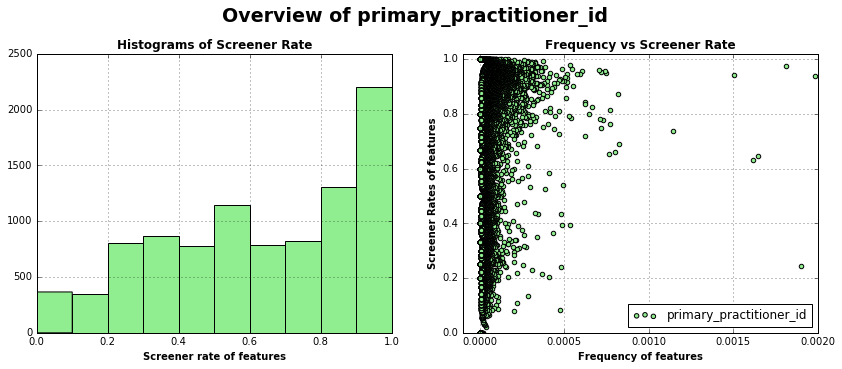

```python
fig = plt.figure(figsize=(14,5))
fig.suptitle('Overview of primary_practitioner_id',fontweight='bold',fontsize=19, y=1.03)
ax = fig.add_subplot(121)
ax.hist(primary_practitioner.screen_rate, color='lightgreen')
ax.set_title('Histograms of Screener Rate',fontweight='bold')
ax.set_xlabel('Screener rate of features',fontweight='bold')
#plt.ylim(0,110)
plt.grid()
#plt.show()

ax2 = fig.add_subplot(122)
ax2.scatter(primary_practitioner.frequency,primary_practitioner.screen_rate,c='lightgreen',label='primary_practitioner_id')
ax2.set_title('Frequency vs Screener Rate',fontweight='bold')
ax2.set_xlabel('Frequency of features',fontweight='bold')
ax2.set_ylabel('Screener Rates of features',fontweight='bold')
ax2.legend(loc='lower right')
plt.xlim(-0.0001,0.002)
plt.ylim(0,1.02)
plt.grid()
fig.subplots_adjust(wspace=0.2)
plt.show()
```

#### The histogram plot shows that more than 2000 practitioner ids correspond to a screener rate greater than 0.9. However, most of them are very infrequent. The scatter plot on the right shows that there are three practitioner IDs that correspond to screener rate greater than 0.9 and frequency greater than 0.1%, which are "16444459", "12709441", and "14015592". So who are these practitioners?

## Insight 6: Some practitioners' job directly relates to screening or cervical cancer.

```python
pmap=pd.read_csv('../input/physicians.csv')
mask=pmap['practitioner_id'].isin([16444459, 12709441, 14015592])
pmap[mask]
```

|  | physician_id | practitioner_id | state | specialty_code | specialty_description | CBSA |
| --- | --- | --- | --- | --- | --- | --- |
| 109453 | 12709441 | 12709441 | CA | DR | DIAGNOSTIC RADIOLOGY | 41860 |
| 430336 | 14015592 | 14015592 | CA | DR | DIAGNOSTIC RADIOLOGY | 41860 |
| 677594 | 13116555 | 16444459 | CA | OBG | OBSTETRICS AND GYNECOLOGY | 41860 |

#### Apparently their jobs are strongly related to screening. Interesting thing is they are all from the same location of California.

#### There is one practitioner ID that correspond to screener rate smaller than 0.3 and frequency greater than 0.1%, which is "29416393"

```python
pmap=pd.read_csv('../input/physicians.csv')
mask=pmap['practitioner_id'].isin([29416393])
pmap[mask]
```

|  | physician_id | practitioner_id | state | specialty_code | specialty_description | CBSA |
| --- | --- | --- | --- | --- | --- | --- |
| 896215 | 14074837 | 29416393 | WA | VIR | VASCULAR AND INTERVENTIONAL RADIOLOGY | 49420 |

#### Frequent and strong primary_practitioner_id predictors

```python
mask=(primary_practitioner.frequency>0.001)
primary_practitioner[mask].sort(columns='screen_rate',axis=0,ascending=False)[:10]
```

|  | index | feature | weight | screen_rate | frequency | description |
| --- | --- | --- | --- | --- | --- | --- |
| 483 | 265094781 | 16444459 | 0.261919 | 0.977121 | 0.001812 | primary_practitioner_id |
| 6360 | 167728366 | 12709441 | 0.107799 | 0.943775 | 0.001505 | primary_practitioner_id |
| 5151 | 56116597 | 14015592 | 0.122118 | 0.937310 | 0.001984 | primary_practitioner_id |
| 3102 | 123644336 | 14370881 | 0.101691 | 0.736405 | 0.001144 | primary_practitioner_id |
| 2375 | 262447155 | 14007032 | 0.139398 | 0.645636 | 0.001643 | primary_practitioner_id |
| 4688 | 241647461 | 12945837 | 0.123303 | 0.631748 | 0.001616 | primary_practitioner_id |
| 159 | 12255777 | 29416393 | -0.102089 | 0.244323 | 0.001902 | primary_practitioner_id |

## Insight 7: Nurse's experience matters

```python
physicains=pd.read_csv('../online2/feamap12.csv').sort(columns='frequency',axis=0,ascending=False)
physicains
```

|  | index | feature | weight | screen_rate | frequency | description |
| --- | --- | --- | --- | --- | --- | --- |
| 8 | 240540920 | GYN | 0.050469 | 0.714609 | 0.116578 | specialty_code |
| 6 | 202466831 | DMP | 0.052519 | 0.649283 | 0.039235 | specialty_code |
| 7 | 28074032 | NMW | 0.076270 | 0.812271 | 0.024508 | specialty_code |
| 0 | 90934848 | SP | 0.055063 | 0.664782 | 0.018182 | specialty_code |
| 3 | 16614087 | FOP | 0.054828 | 0.660666 | 0.001583 | specialty_code |
| 5 | 103656617 | PLM | -0.062786 | 0.476569 | 0.000977 | specialty_code |
| 1 | 118656641 | PCH | 0.073176 | 0.635379 | 0.000239 | specialty_code |
| 4 | 124656680 | PYA | -0.075508 | 0.619048 | 0.000054 | specialty_code |
| 2 | 170165281 | SNP | -0.059112 | 0.250000 | 0.000014 | specialty_code |

#### The only features that the algorithm found useful in physicians.csv is specialty code. The table above shows that the specialty code NMW, NURSE MIDWIFE, correspond to 81% screener rate and 2.4% frequency which is the most useful indicator for screeners. The specialty code SNP, SCHOOL NURSE PRACTITIONER, strongly indicate non-screeners but it is not frequent. A simple googling shows that NMW is certified practitioners while SNP is obviously less experienced, which makes intuitive sense.